# STAT 420 Final Project - National Life Expectancy prediction

xinyupi2

2019年7月22日

# Introduction

## About our Data

We found the dataset from @Kaggle. The website where we get this dataset is https://www.kaggle.com/kumarajarshi/life-expectancy-who. According to the author, the data was collected from WHO and United Nations website.

We all have some personal interest in biology and health science, and how long a person can live is certianly one of the most important and mysterious questions in the two fields. Thinking about this question purely from the perspective of biology theory can make it too complicated. But this dataset brings us another point of view: thinking about this question from the perspective of a statistician. So we are really interested in exploring this dataset, and we hope to build a model of life expectancy using other factors with high accuracy.

## A view of the data(Explortory Data Analysis)

```r
life_data = read.csv("Life Expectancy Data.csv")
# View(life_data)
```

```r
## an overview of data
summary(life_data)
```

```
##                 Country          Year             Status
##  Afghanistan        :  16   Min.   :2000   Developed : 512
##  Albania            :  16   1st Qu.:2004   Developing:2426
##  Algeria            :  16   Median :2008
##  Angola             :  16   Mean   :2008
##  Antigua and Barbuda:  16   3rd Qu.:2012
##  Argentina          :  16   Max.   :2015
##  (Other)            :2842
##  Life.expectancy Adult.Mortality infant.deaths       Alcohol
##  Min.   :36.30   Min.   :  1.0   Min.   :   0.0   Min.   : 0.0100
##  1st Qu.:63.10   1st Qu.: 74.0   1st Qu.:   0.0   1st Qu.: 0.8775
##  Median :72.10   Median :144.0   Median :   3.0   Median : 3.7550
##  Mean   :69.22   Mean   :164.8   Mean   :  30.3   Mean   : 4.6029
##  3rd Qu.:75.70   3rd Qu.:228.0   3rd Qu.:  22.0   3rd Qu.: 7.7025
##  Max.   :89.00   Max.   :723.0   Max.   :1800.0   Max.   :17.8700
##  NA's   :10      NA's   :10                       NA's   :194
##  percentage.expenditure  Hepatitis.B       Measles              BMI
##  Min.   :    0.000      Min.   : 1.00   Min.   :     0.0   Min.   : 1.00
##  1st Qu.:    4.685      1st Qu.:77.00   1st Qu.:     0.0   1st Qu.:19.30
##  Median :   64.913      Median :92.00   Median :    17.0   Median :43.50
##  Mean   :  738.251      Mean   :80.94   Mean   :  2419.6   Mean   :38.32
##  3rd Qu.:  441.534      3rd Qu.:97.00   3rd Qu.:   360.2   3rd Qu.:56.20
##  Max.   :19479.912      Max.   :99.00   Max.   :212183.0   Max.   :87.30
##                         NA's   :553                        NA's   :34
##  under.five.deaths     Polio       Total.expenditure   Diphtheria
##  Min.   :   0.00   Min.   : 3.00   Min.   : 0.370    Min.   : 2.00
##  1st Qu.:   0.00   1st Qu.:78.00   1st Qu.: 4.260    1st Qu.:78.00
##  Median :   4.00   Median :93.00   Median : 5.755    Median :93.00
##  Mean   :  42.04   Mean   :82.55   Mean   : 5.938    Mean   :82.32
##  3rd Qu.:  28.00   3rd Qu.:97.00   3rd Qu.: 7.492    3rd Qu.:97.00
##  Max.   :2500.00   Max.   :99.00   Max.   :17.600    Max.   :99.00
##                    NA's   :19      NA's   :226       NA's   :19
##     HIV.AIDS           GDP              Population
##  Min.   : 0.100   Min.   :     1.68   Min.   :3.400e+01
##  1st Qu.: 0.100   1st Qu.:   463.94   1st Qu.:1.958e+05
##  Median : 0.100   Median :  1766.95   Median :1.387e+06
##  Mean   : 1.742   Mean   :  7483.16   Mean   :1.275e+07
##  3rd Qu.: 0.800   3rd Qu.:  5910.81   3rd Qu.:7.420e+06
##  Max.   :50.600   Max.   :119172.74   Max.   :1.294e+09
##                   NA's   :448         NA's   :652
##  thinness..1.19.years thinness.5.9.years Income.composition.of.resources
##  Min.   : 0.10        Min.   : 0.10      Min.   :0.0000
##  1st Qu.: 1.60        1st Qu.: 1.50      1st Qu.:0.4930
##  Median : 3.30        Median : 3.30      Median :0.6770
##  Mean   : 4.84        Mean   : 4.87      Mean   :0.6276
##  3rd Qu.: 7.20        3rd Qu.: 7.20      3rd Qu.:0.7790
##  Max.   :27.70        Max.   :28.60      Max.   :0.9480
##  NA's   :34           NA's   :34         NA's   :167
##    Schooling
##  Min.   : 0.00
##  1st Qu.:10.10
##  Median :12.30
##  Mean   :11.99
##  3rd Qu.:14.30
##  Max.   :20.70
##  NA's   :163
```

```r
#drop the country column and this is not useful for predicting
life_data = subset(life_data, select=-c(Country))

#data overview
names(life_data)
```

```
##  [1] "Year"                            "Status"
##  [3] "Life.expectancy"                 "Adult.Mortality"
##  [5] "infant.deaths"                   "Alcohol"
##  [7] "percentage.expenditure"          "Hepatitis.B"
##  [9] "Measles"                         "BMI"
## [11] "under.five.deaths"               "Polio"
## [13] "Total.expenditure"               "Diphtheria"
## [15] "HIV.AIDS"                        "GDP"
## [17] "Population"                      "thinness..1.19.years"
## [19] "thinness.5.9.years"              "Income.composition.of.resources"
## [21] "Schooling"
```

```r
head(life_data,10)
```

```
##    Year     Status Life.expectancy Adult.Mortality infant.deaths Alcohol
## 1  2015 Developing            65.0             263            62    0.01
## 2  2014 Developing            59.9             271            64    0.01
## 3  2013 Developing            59.9             268            66    0.01
## 4  2012 Developing            59.5             272            69    0.01
## 5  2011 Developing            59.2             275            71    0.01
## 6  2010 Developing            58.8             279            74    0.01
## 7  2009 Developing            58.6             281            77    0.01
## 8  2008 Developing            58.1             287            80    0.03
## 9  2007 Developing            57.5             295            82    0.02
## 10 2006 Developing            57.3             295            84    0.03
##    percentage.expenditure Hepatitis.B Measles  BMI under.five.deaths Polio
## 1               71.279624          65    1154 19.1                83     6
## 2               73.523582          62     492 18.6                86    58
## 3               73.219243          64     430 18.1                89    62
```

[output cut: 40 more lines]

```r
cat("The data has", nrow(life_data), "rows")
```

```
## The data has 2938 rows
```

```r
cat("and", ncol(life_data), "columns")
```

```
## and 21 columns
```

```r
##See the data types and levels
str(life_data)
```

```
## 'data.frame':    2938 obs. of  21 variables:
##  $ Year                           : int  2015 2014 2013 2012 2011 2010 2009 2008 2007 2006 ...
##  $ Status                         : Factor w/ 2 levels "Developed","Developing": 2 2 2 2 2 2 2 2 2 2 ...
##  $ Life.expectancy                : num  65 59.9 59.9 59.5 59.2 58.8 58.6 58.1 57.5 57.3 ...
##  $ Adult.Mortality                : int  263 271 268 272 275 279 281 287 295 295 ...
##  $ infant.deaths                  : int  62 64 66 69 71 74 77 80 82 84 ...
##  $ Alcohol                        : num  0.01 0.01 0.01 0.01 0.01 0.01 0.01 0.03 0.02 0.03 ...
##  $ percentage.expenditure         : num  71.3 73.5 73.2 78.2 7.1 ...
##  $ Hepatitis.B                    : int  65 62 64 67 68 66 63 64 63 64 ...
##  $ Measles                        : int  1154 492 430 2787 3013 1989 2861 1599 1141 1990 ...
##  $ BMI                            : num  19.1 18.6 18.1 17.6 17.2 16.7 16.2 15.7 15.2 14.7 ...
##  $ under.five.deaths              : int  83 86 89 93 97 102 106 110 113 116 ...
##  $ Polio                          : int  6 58 62 67 68 66 63 64 63 58 ...
##  $ Total.expenditure              : num  8.16 8.18 8.13 8.52 7.87 9.2 9.42 8.33 6.73 7.43 ...
##  $ Diphtheria                     : int  65 62 64 67 68 66 63 64 63 58 ...
##  $ HIV.AIDS                       : num  0.1 0.1 0.1 0.1 0.1 0.1 0.1 0.1 0.1 0.1 ...
##  $ GDP                            : num  584.3 612.7 631.7 670 63.5 ...
##  $ Population                     : num  33736494 327582 31731688 3696958 2978599 ...
##  $ thinness..1.19.years           : num  17.2 17.5 17.7 17.9 18.2 18.4 18.6 18.8 19 19.2 ...
##  $ thinness.5.9.years             : num  17.3 17.5 17.7 18 18.2 18.4 18.7 18.9 19.1 19.3 ...
##  $ Income.composition.of.resources: num  0.479 0.476 0.47 0.463 0.454 0.448 0.434 0.433 0.415 0.405 ...
##  $ Schooling                      : num  10.1 10 9.9 9.8 9.5 9.2 8.9 8.7 8.4 8.1 ...
```

```r
levels(life_data$Status)
```

```
## [1] "Developed"  "Developing"
```

```r
# check which columns has NA values.
anyNA(life_data)
```

```
## [1] TRUE
```

```r
cols_has_na = names(life_data)[colSums(is.na(life_data)) != 0]
cols_has_na
```

```
##  [1] "Life.expectancy"                 "Adult.Mortality"
##  [3] "Alcohol"                         "Hepatitis.B"
##  [5] "BMI"                             "Polio"
##  [7] "Total.expenditure"               "Diphtheria"
##  [9] "GDP"                             "Population"
## [11] "thinness..1.19.years"            "thinness.5.9.years"
## [13] "Income.composition.of.resources" "Schooling"
```

```r
cat(length(cols_has_na), "columns has na values. Status, the categorical variable, does not contain any na.")
```

```
## 14 columns has na values. Status, the categorical variable, does not contain any na.
```

# Methods

## A general overview

- Handling missing data

we will be using pakcage “mice” to impute all the missing data with random forest(5th time) to make the prediction each better.

- Modeling

Linear: we will fit a additive full model, a raw AIC model, and aa model selected based on AIC. Non-linear: We will fit a random forest regression model and a KNN(both with and without scaling) model and compare these non-linear models to MLR. The results from random forest would be used to interpret the importances of features.

- Feature Selection

Generalization indicator: LOOCV RMSE for linear model, test RMSE for non-linear model. This is because training of random forest is too expensive.

Diagnostic: Ajusted R square, Influential points, QQ plot, residual vs. fitted, shapiro test, bp test will be used for selecting the features for MLR. Non-linear models is not the big focus of this project so feature engineering would be limited.

## Pacakges will be used

```r
library(caret)
library(lmtest)
library(faraway)
library(mice)
library(randomForest)
library(lmtest)
library(knitr)
```

## Handling missing data and highly correlated data

```r
### we drop the rows whose reponse is NA
life_data = life_data[!is.na(life_data$Life.expectancy),]
cat("now the data has",nrow(life_data),"observations and",ncol(life_data),"features")
```

```
## now the data has 2928 observations and 21 features
```

```r
# check all the NA's have been removed and see the new data
life_data = read.csv("life_data.csv")
life_data = subset(life_data, select = -c(1))
summary(life_data)
```

```
##       Year             Status     Life.expectancy Adult.Mortality
##  Min.   :2000   Developed : 512   Min.   :36.30   Min.   :  1.0
##  1st Qu.:2004   Developing:2416   1st Qu.:63.10   1st Qu.: 74.0
##  Median :2008                     Median :72.10   Median :144.0
##  Mean   :2008                     Mean   :69.22   Mean   :164.8
##  3rd Qu.:2011                     3rd Qu.:75.70   3rd Qu.:228.0
##  Max.   :2015                     Max.   :89.00   Max.   :723.0
##  infant.deaths        Alcohol       percentage.expenditure  Hepatitis.B
##  Min.   :   0.00   Min.   : 0.010   Min.   :    0.000      Min.   : 1.00
##  1st Qu.:   0.00   1st Qu.: 0.590   1st Qu.:    4.854      1st Qu.:73.00
##  Median :   3.00   Median : 3.520   Median :   65.611      Median :91.00
##  Mean   :  30.41   Mean   : 4.458   Mean   :  740.321      Mean   :78.91
##  3rd Qu.:  22.00   3rd Qu.: 7.550   3rd Qu.:  442.614      3rd Qu.:96.00
##  Max.   :1800.00   Max.   :17.870   Max.   :19479.912      Max.   :99.00
##     Measles              BMI        under.five.deaths     Polio
##  Min.   :     0.0   Min.   : 1.00   Min.   :   0.00   Min.   : 3.00
##  1st Qu.:     0.0   1st Qu.:19.10   1st Qu.:   0.00   1st Qu.:78.00
##  Median :    17.0   Median :43.00   Median :   4.00   Median :93.00
##  Mean   :  2427.9   Mean   :37.99   Mean   :  42.18   Mean   :82.57
##  3rd Qu.:   362.2   3rd Qu.:56.10   3rd Qu.:  28.00   3rd Qu.:97.00
##  Max.   :212183.0   Max.   :77.60   Max.   :2500.00   Max.   :99.00
##  Total.expenditure   Diphtheria       HIV.AIDS           GDP
##  Min.   : 0.370    Min.   : 2.00   Min.   : 0.100   Min.   :     1.68
##  1st Qu.: 4.260    1st Qu.:78.00   1st Qu.: 0.100   1st Qu.:   392.82
##  Median : 5.725    Median :93.00   Median : 0.100   Median :  1439.39
##  Mean   : 5.927    Mean   :82.34   Mean   : 1.748   Mean   :  6778.67
##  3rd Qu.: 7.470    3rd Qu.:97.00   3rd Qu.: 0.800   3rd Qu.:  5335.76
##  Max.   :17.600    Max.   :99.00   Max.   :50.600   Max.   :119172.74
##    Population        thinness..1.19.years thinness.5.9.years
##  Min.   :3.400e+01   Min.   : 0.100       Min.   : 0.100
##  1st Qu.:1.907e+05   1st Qu.: 1.600       1st Qu.: 1.600
##  Median :1.351e+06   Median : 3.400       Median : 3.400
##  Mean   :1.210e+07   Mean   : 4.878       Mean   : 4.908
##  3rd Qu.:7.463e+06   3rd Qu.: 7.200       3rd Qu.: 7.300
##  Max.   :1.294e+09   Max.   :27.700       Max.   :28.600
##  Income.composition.of.resources   Schooling
##  Min.   :0.0000                  Min.   : 0.00
##  1st Qu.:0.4880                  1st Qu.:10.10
##  Median :0.6755                  Median :12.30
##  Mean   :0.6229                  Mean   :11.98
##  3rd Qu.:0.7802                  3rd Qu.:14.30
##  Max.   :0.9480                  Max.   :20.70
```

```r
cor_mat = cor(subset(life_data, select=-c(2)))
cor_mat
```

```
##                                        Year Life.expectancy
## Year                             1.00000000      0.17003302
## Life.expectancy                  0.17003302      1.00000000
## Adult.Mortality                 -0.07905159     -0.69635931
## infant.deaths                   -0.03646405     -0.19655718
## Alcohol                         -0.10240924      0.38681485
## percentage.expenditure           0.03272257      0.38186350
## Hepatitis.B                      0.16482515      0.34939521
## Measles                         -0.08184033     -0.15758580
## BMI                              0.10410611      0.57334044
## under.five.deaths               -0.04197985     -0.22252912
## Polio                            0.09351400      0.46254453
## Total.expenditure                0.08379779      0.21924793
## Diphtheria                       0.13282994      0.47628734
## HIV.AIDS                        -0.13878854     -0.55655625
## GDP                              0.09485729      0.44300460
## Population                       0.01829211     -0.03552482
## thinness..1.19.years            -0.04239973     -0.47411907
## thinness.5.9.years              -0.04636332     -0.46836129
## Income.composition.of.resources  0.23422808      0.71063151
## Schooling                        0.20561002      0.74723863
##                                 Adult.Mortality infant.deaths     Alcohol
## Year                              -0.0790515894   -0.03646405 -0.10240924
## Life.expectancy                   -0.6963593138   -0.19655718  0.38681485
## Adult.Mortality                    1.0000000000    0.07875601 -0.19034231
## infant.deaths                      0.0787560117    1.00000000 -0.11167407
## Alcohol                           -0.1903423135   -0.11167407  1.00000000
## percentage.expenditure            -0.2428595283   -0.08590584  0.34092695
## Hepatitis.B                       -0.2069469484   -0.21944382  0.12949216
## Measles                            0.0311764119    0.50103772 -0.04793560
## BMI                               -0.3942273941   -0.22712775  0.32206422
## under.five.deaths                  0.0941461272    0.99662815 -0.10854760
## Polio                             -0.2743173607   -0.17095205  0.21744974
## Total.expenditure                 -0.1175450172   -0.12913785  0.29570304
## Diphtheria                        -0.2748298071   -0.17537304  0.21295734
## HIV.AIDS                           0.5238205079    0.02495467 -0.04232854
## GDP                               -0.2913972211   -0.10415209  0.32527981
## Population                        -0.0001027216    0.55289214 -0.03713300
## thinness..1.19.years               0.3015995498    0.46295685 -0.41534054
## thinness.5.9.years                 0.3084199130    0.46870946 -0.40497616
```

[output cut: 134 more lines]

```
## percentage.expenditure           0.37565388
## Hepatitis.B                      0.31020657
## Measles                         -0.15782322
## BMI                              0.55693962
## under.five.deaths               -0.22119142
## Polio                            0.40040506
## Total.expenditure                0.27343881
## Diphtheria                       0.41759877
## HIV.AIDS                        -0.21977127
## GDP                              0.43498892
## Population                      -0.03967781
## thinness..1.19.years            -0.47011917
## thinness.5.9.years              -0.45915272
## Income.composition.of.resources  0.79092723
## Schooling                        1.00000000
```

```r
drop_index= which(cor(subset(life_data, select=-c(2)))  > 0.9 &
                    cor(subset(life_data, select=-c(2))) < 1)
cor_mat[drop_index]
```

```
## [1] 0.9966281 0.9966281 0.9352766 0.9352766
```

```r
drop_index
```

```
## [1]  70 184 338 357
```

```r
## drop the columns
life_data = subset(life_data, select=-c(under.five.deaths, thinness.5.9.years))
```

```r
### do the train_test_split
set.seed(1969)
split = rbinom(0.66, size = 1, n = nrow(life_data))
sum(split == 0)
```

```
## [1] 1016
```

```r
train_data = life_data[split == 1,]
test_data = life_data[!split == 0,]
```

## Data Visuailzation

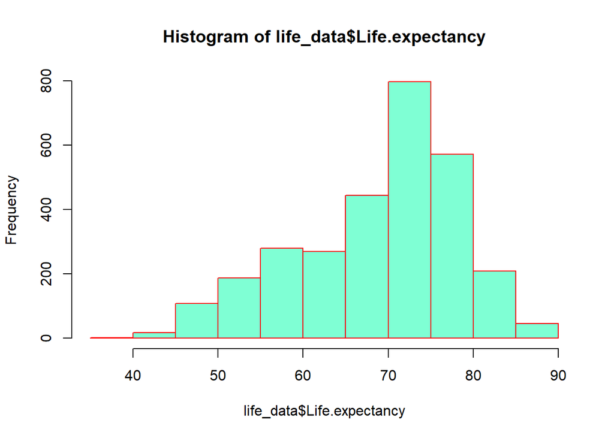

```r
hist(life_data$Life.expectancy, col = "aquamarine", border = "red")
```

## Feature Engineering

```r
### change the year to year_i - min(year)
life_data$Year = life_data$Year - min(life_data$Year)
```

It’s a commonly used trick to make scales the years to max(year) - min(year), or current - year to make the years have higher contrast from each other.

## Helper functions

```r
##### Scoring tool kits

##RMSE
calc_loocv_rmse = function(model) {
  sqrt(mean((resid(model) / (1 - hatvalues(model))) ^ 2))
}

calc_rmse = function(predicted, actual) {
  return(sqrt(mean((predicted - actual)^2)))
}

## calculate test performace in one step
test_rmse = function(model_name, model) {
  pred = predict(model, test_data)
  cat("Model", model_name, "has test rmse:",
      calc_rmse(predicted=pred, actual=test_data$Life.expectancy))
}
```

## Full additive model

```r
full_additive = lm(data = life_data, Life.expectancy ~ .)
cat("\nAdjusted R^2:", summary(full_additive)$adj)
```

```
##
## Adjusted R^2: 0.8194621
```

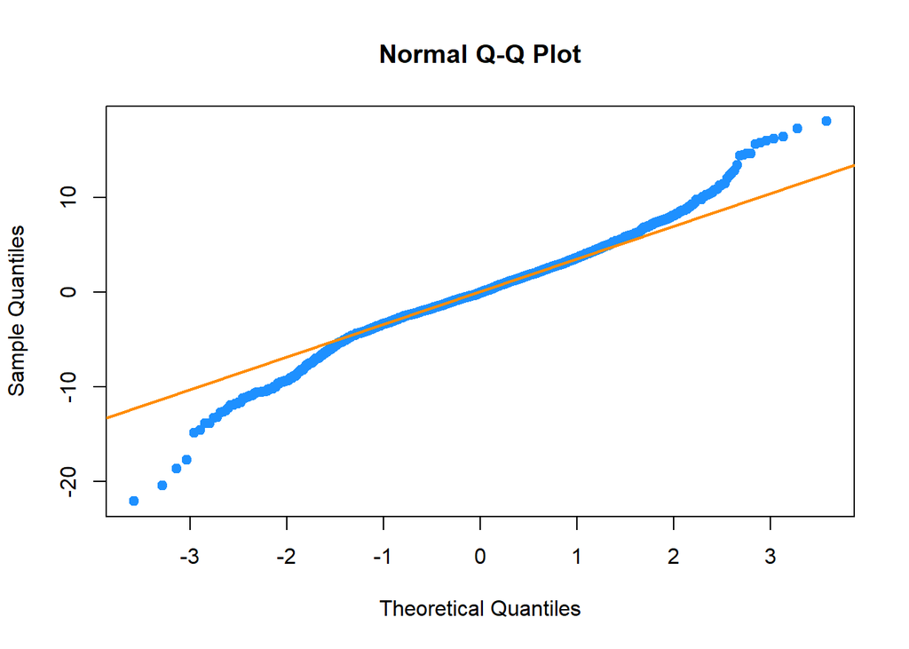

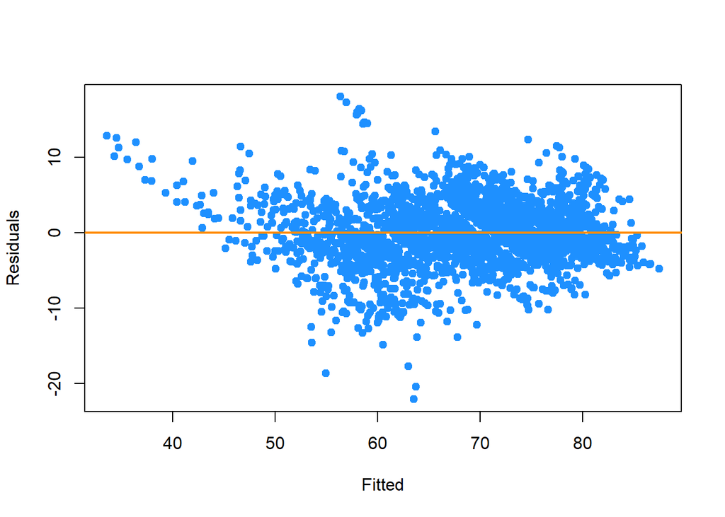

```
## shapiro test p-value : 1.614711e-19
##  the normality assumption was violated
##  bptest p-value : 4.295118e-83
##  the equal variance assumption was violated
```

```r
check_assumptions(full_additive)
```

```r
test_rmse("\nfull additive", full_additive)
```

```
## Model
## full additive has test rmse: 61.64631
```

```r
cat("\nLOOCV rmse:",calc_loocv_rmse(full_additive))
```

```
##
## LOOCV rmse: 4.068498
```

This is not good enough. All assumptions are violated and test rmse is really high because of unusual obersvations

## AIC selection Model

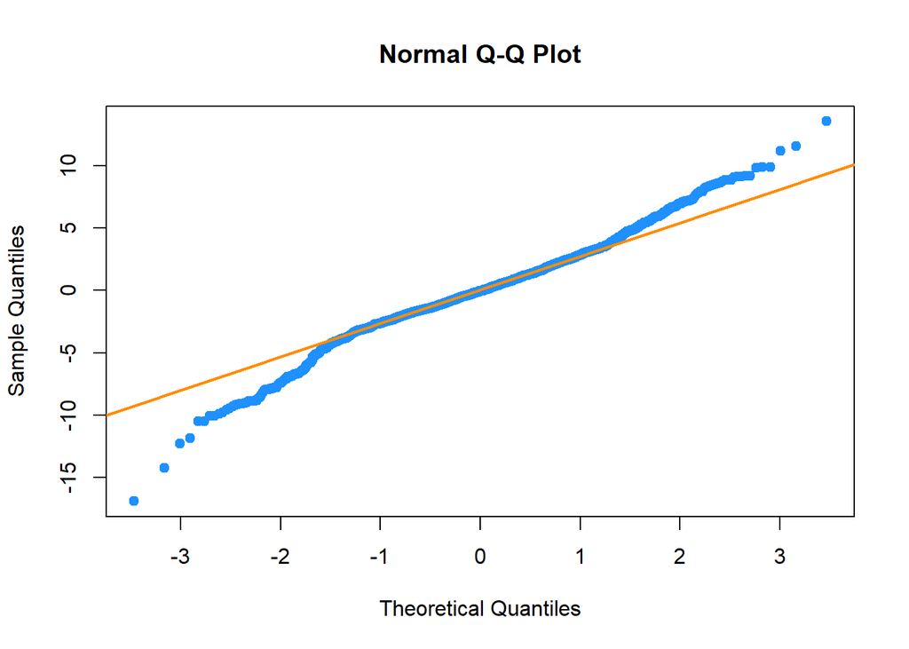

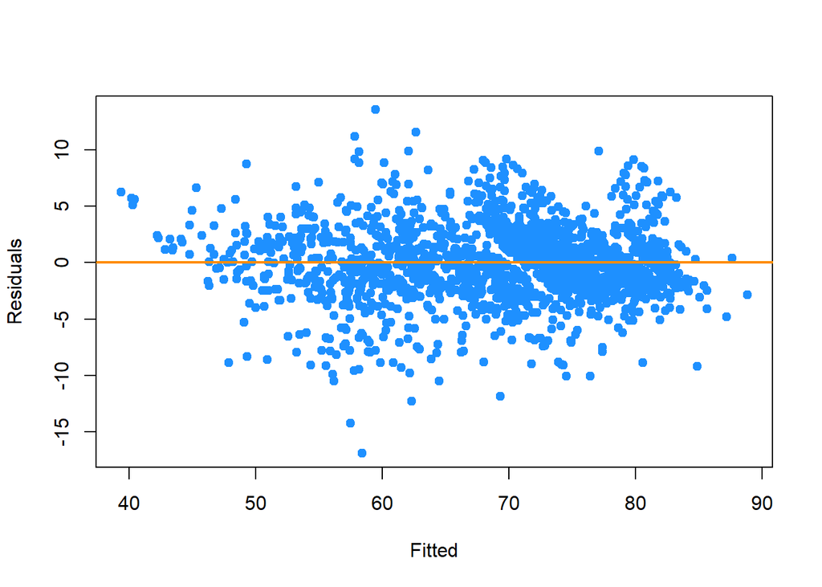

```
## shapiro test p-value : 2.115756e-15
##  the normality assumption was violated
##  bptest p-value : 2.510088e-21
##  the equal variance assumption was violated
```

```r
##############
############## This is the model chosen by aic initially. (begin with . ^ 2)
aic_ini = lm(formula = Life.expectancy ~ Year + Status + Adult.Mortality +
    infant.deaths + Alcohol + percentage.expenditure + Hepatitis.B +
    Measles + BMI + Polio + Total.expenditure + Diphtheria +
    HIV.AIDS + GDP + Population + thinness..1.19.years + Income.composition.of.resources +
    Schooling + Year:infant.deaths + Year:Alcohol + Year:Measles +
    Year:HIV.AIDS + Year:GDP + Year:thinness..1.19.years + Year:Income.composition.of.resources +
    Year:Schooling + Status:Adult.Mortality + Status:Alcohol +
    Status:Hepatitis.B + Status:BMI + Status:Total.expenditure +
    Status:Population + Status:thinness..1.19.years + Status:Schooling +
    Adult.Mortality:Alcohol + Adult.Mortality:percentage.expenditure +
    Adult.Mortality:BMI + Adult.Mortality:Total.expenditure +
    Adult.Mortality:Diphtheria + Adult.Mortality:HIV.AIDS + Adult.Mortality:GDP +
    Adult.Mortality:thinness..1.19.years + Adult.Mortality:Schooling +
    infant.deaths:Measles + infant.deaths:BMI + infant.deaths:Polio +
    infant.deaths:Total.expenditure + infant.deaths:Diphtheria +
    infant.deaths:Population + infant.deaths:Income.composition.of.resources +
    infant.deaths:Schooling + Alcohol:Hepatitis.B + Alcohol:Measles +
    Alcohol:Polio + Alcohol:Total.expenditure + Alcohol:HIV.AIDS +
    Alcohol:Population + Alcohol:thinness..1.19.years + Alcohol:Income.composition.of.resources +
    Alcohol:Schooling + percentage.expenditure:BMI + percentage.expenditure:thinness..1.19.years +
    Hepatitis.B:Measles + Hepatitis.B:Polio + Hepatitis.B:Total.expenditure +
    Hepatitis.B:Diphtheria + Hepatitis.B:Income.composition.of.resources +
    Measles:Polio + Measles:Diphtheria + BMI:Diphtheria + BMI:thinness..1.19.years +
    BMI:Income.composition.of.resources + BMI:Schooling + Polio:Diphtheria +
    Polio:GDP + Polio:Schooling + Total.expenditure:Diphtheria +
    Total.expenditure:HIV.AIDS + Total.expenditure:GDP + Total.expenditure:Population +
    Total.expenditure:thinness..1.19.years + Total.expenditure:Schooling +
    HIV.AIDS:GDP + HIV.AIDS:Population + HIV.AIDS:Income.composition.of.resources +
    HIV.AIDS:Schooling + GDP:thinness..1.19.years + GDP:Income.composition.of.resources +
    GDP:Schooling + Population:Income.composition.of.resources +
    thinness..1.19.years:Income.composition.of.resources + thinness..1.19.years:Schooling +
    Income.composition.of.resources:Schooling, data = train_data)
check_assumptions(aic_ini)
```

```r
cat("\nmodel adj.R^2 :", summary(aic_ini)$adj, "\n")
```

```
##
## model adj.R^2 : 0.8796093
```

```r
test_rmse("AIC linear", aic_ini)
```

```
## Model AIC linear has test rmse: 3.20321
```

```r
cat("\nLoocv is:", calc_loocv_rmse(aic_ini), "\n")
```

```
##
## Loocv is: 3.450851
```

If we choose BIC, the penalty is too large so that the full model was surprisingly reduced to only one parameter(the mean of all life expectancy). So we choose AIC instead. There’s so much parameters so we might had better give up the three way interactions.

This model makes a lot more sense, however, both assumptions are violated. We will try to make some improvement on this.

## Our best linear model after manual selection

```r
###### use AIC to choose feature, takes super long to run!!
# full_model = lm(data = train_data, Life.expectancy ~ . ^ 2)
# best_model = step(full_model, direction="backward",trace=0)
```

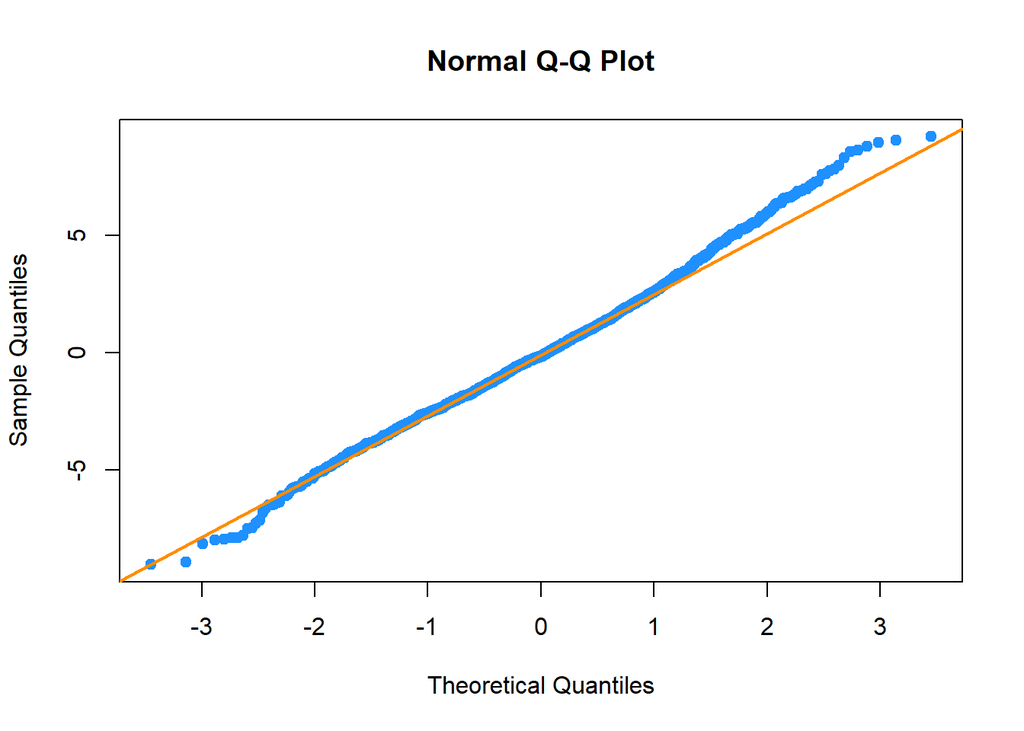

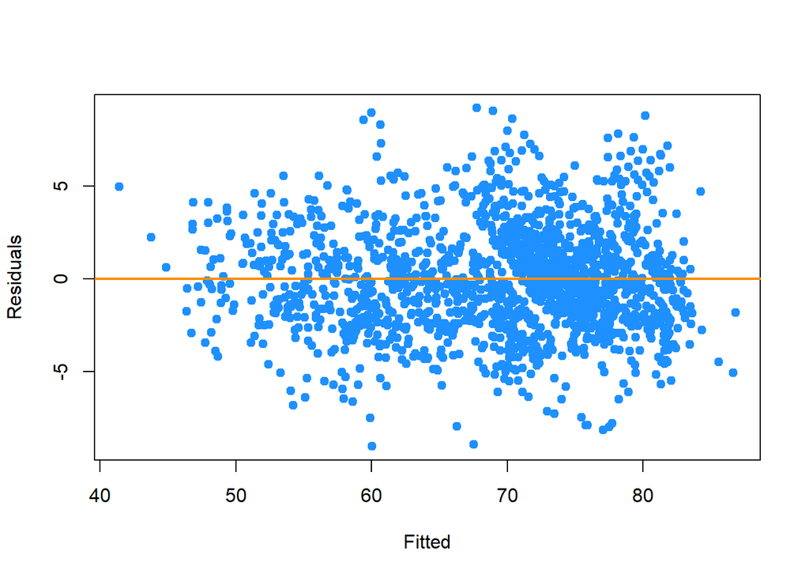

```
## shapiro test p-value : 7.362058e-06
##  the normality assumption was violated
##  bptest p-value : 0.08418819
##  the equal variance assumption was not violated
```

```r
### This is the best multi-linear regression model we can make for this problem
best_model = lm(formula = Life.expectancy ~ Year +
    poly(infant.deaths,2) + poly(percentage.expenditure,2) + poly(Hepatitis.B, 2) +
    I(Measles ^ 2) + poly(BMI,3) + poly(Polio,2) +  poly(Diphtheria,3) +
    poly(HIV.AIDS, 3) + GDP + poly(Population,2) +
    poly(Schooling,2) +Income.composition.of.resources +
    Status:Adult.Mortality  +
    Status:Hepatitis.B  + Status:thinness..1.19.years +
    Adult.Mortality:Alcohol  +
    Adult.Mortality:Diphtheria + Adult.Mortality:HIV.AIDS + Adult.Mortality:GDP + Adult.Mortality:Schooling +
    infant.deaths:Measles + infant.deaths:BMI +
    infant.deaths:Total.expenditure + Alcohol:Measles +
    Alcohol:Polio + Alcohol:HIV.AIDS +
    Alcohol:Population  + Alcohol:Income.composition.of.resources +
     percentage.expenditure:BMI +
    Hepatitis.B:Diphtheria + Hepatitis.B:Income.composition.of.resources  + BMI:Schooling + Polio:Diphtheria +
    Total.expenditure:HIV.AIDS +
     Total.expenditure:Schooling +
    GDP:Schooling + thinness..1.19.years:Schooling, data = train_data)
non_influential_idx = cooks.distance(best_model) <= 4 / length(cooks.distance(best_model))
train_wo_influential = train_data[non_influential_idx, ]

best_model_wo_influential = lm(formula = Life.expectancy ~ Year +
    poly(infant.deaths,2) + poly(percentage.expenditure,2) + poly(Hepatitis.B, 2) +
    I(Measles ^ 2) + poly(BMI,3) + poly(Polio,2) +  poly(Diphtheria,3) +
    poly(HIV.AIDS, 3) + GDP + poly(Population,2) +
    poly(Schooling,2) +Income.composition.of.resources +
    Status:Adult.Mortality  +
    Status:Hepatitis.B  + Status:thinness..1.19.years +
    Adult.Mortality:Alcohol  +
    Adult.Mortality:Diphtheria + Adult.Mortality:HIV.AIDS + Adult.Mortality:GDP + Adult.Mortality:Schooling +
    infant.deaths:Measles + infant.deaths:BMI +
    infant.deaths:Total.expenditure + Alcohol:Measles +
    Alcohol:Polio + Alcohol:HIV.AIDS +
    Alcohol:Population  + Alcohol:Income.composition.of.resources +
     percentage.expenditure:BMI +
    Hepatitis.B:Diphtheria + Hepatitis.B:Income.composition.of.resources  + BMI:Schooling + Polio:Diphtheria +
    Total.expenditure:HIV.AIDS +
     Total.expenditure:Schooling +
    GDP:Schooling + Population:Income.composition.of.resources  + thinness..1.19.years:Schooling, data = train_wo_influential)
check_assumptions(best_model_wo_influential)
```

```r
cat("\nmodel adj.R^2 :", summary(best_model_wo_influential)$adj, "\n")
```

```
##
## model adj.R^2 : 0.9024191
```

```r
test_rmse("AIC linear", best_model_wo_influential)
```

```
## Model AIC linear has test rmse: 3.403834
```

```r
cat("\nLoocv is:", calc_loocv_rmse(best_model_wo_influential), "\n")
```

```
##
## Loocv is: 2.8191
```

```r
vif(best_model_wo_influential)
```

```
##                                        Year
##                                1.338897e+00
##                     poly(infant.deaths, 2)1
##                                4.884539e+01
##                     poly(infant.deaths, 2)2
##                                7.226052e+00
##            poly(percentage.expenditure, 2)1
##                                2.535296e+01
##            poly(percentage.expenditure, 2)2
##                                1.283999e+00
##                       poly(Hepatitis.B, 2)1
##                                2.469494e+01
##                       poly(Hepatitis.B, 2)2
##                                2.522269e+00
##                                I(Measles^2)
##                                2.701284e+00
##                               poly(BMI, 3)1
##                                6.598683e+01
##                               poly(BMI, 3)2
##                                1.488535e+00
##                               poly(BMI, 3)3
##                                1.388269e+00
##                             poly(Polio, 2)1
##                                1.538570e+01
##                             poly(Polio, 2)2
##                                4.725789e+00
##                        poly(Diphtheria, 3)1
##                                2.326166e+01
##                        poly(Diphtheria, 3)2
##                                5.445606e+00
##                        poly(Diphtheria, 3)3
##                                1.322417e+00
##                          poly(HIV.AIDS, 3)1
##                                4.867696e+01
##                          poly(HIV.AIDS, 3)2
##                                1.969458e+00
##                          poly(HIV.AIDS, 3)3
##                                1.821509e+00
##                                         GDP
##                                1.210936e+02
```

[output cut: 53 more lines]

```
##                                6.506612e-01
##                               Schooling:BMI
##                                4.069883e-01
##                            Diphtheria:Polio
##                                2.576285e+05
##                  HIV.AIDS:Total.expenditure
##                                1.246521e+00
##                 Schooling:Total.expenditure
##                                4.991431e-06
##                               GDP:Schooling
##                                2.917815e-03
##  Income.composition.of.resources:Population
##                                8.161897e+12
##              thinness..1.19.years:Schooling
##                                1.142766e+02
```

We can see that after dropping the influential points, we fail to reject null hypothesis of BP test, which means that the model does not violate contant variance assumption. However, p-value of the shapiro test still indicates that the normality assumption is violated. Also, through investigating the variance inflation factor, we can see that there is a huge multicollinearity issue as many of the predictors have a VIF greater than 5. The failure of normality assumption and the multicollinearity issue may due to the loss of some features in the data. These features may provide critical information for the prediction model. Without these information, we may not able to find a linear model which fulfills both assumptions and has little multicollinearity issue.

```r
# lm_drop_outliers
sum(cooks.distance(best_model_wo_influential) > 4 / length(nrow(train_data)))
```

```
## [1] 0
```